# Unit 3: Data Science in Python

### Content:

- NumPy (Basic datatypes for numerical computation)
- SciPy (Standard computational methods built on top of NumPy datatypes)
- Pandas (DataFrames in Python)
- SciKit-learn (Standard Machine Learning algorithms for Python)
- Matplotlib (Plotting in Python)
- Python lists are not equivalent to numerical vectors in languages like R or MATLAB
- Great for general computation, but not for math

```python
list1 = [1, 2, 3]
list2 = [4, 5, 6]
print(list1 * 3)
print(list1 * list2)
```

```
[1, 2, 3, 1, 2, 3, 1, 2, 3]
```

```
---------------------------------------------------------------------------
TypeError                                 Traceback (most recent call last)
<ipython-input-7-b5d2d40deb3b> in <module>()
      2 list2 = [4, 5, 6]
      3 print(list1 * 3)
----> 4 print(list1 * list2)

TypeError: can't multiply sequence by non-int of type 'list'
```

- Python has a built in array datatype
- Practically equivalent to list but with constrained data
- Faster than normal lists when working with homogenous data
- Still not mathematical vectors

```python
import array

array1 = array.array('i', list1)
array2 = array.array('i', list2)
print(array1 * 3)
print(array1 * array2)
```

```
array('i', [1, 2, 3, 1, 2, 3, 1, 2, 3])
```

```
---------------------------------------------------------------------------
TypeError                                 Traceback (most recent call last)
<ipython-input-13-a265ca4eb542> in <module>()
      4 array2 = array.array('i', list2)
      5 print(array1 * 3)
----> 6 print(array1 * array2)

TypeError: can't multiply sequence by non-int of type 'array.array'
```

## NumPy

- Built around the `ndarray` datatype.
  - $n$-dimensional typed array
  - Contains homogenous data of a specific type
  - Vectorized operations
  - Implemented in C, i.e. **fast**
- Contains lots of legacy code for backwards compatibility reasons
  - Anything outside arithmetic operations have SciPy versions
  - Use SciPy
- **Caveats:**
  - NumPy has a `matrix` datatype specifically for 2d-arrays. **AVOID**
  - The `matrix` datatype is less general than `ndarray`, behaves differently and is rarely returned from built-in functions in NumPy or SciPy.
  - NumPy is more similar to R than Python in general but there are still differences to snag on

```python
import numpy as np # It is so common to import numpy as np that it can almost be considered a convention

ndarray1 = np.array(list1)
ndarray2 = np.array(list2)
print(ndarray1 * 40)
print(type(ndarray1 * ndarray2))
print(ndarray1 * ndarray2)
```

```
[ 40  80 120]
<class 'numpy.ndarray'>
[ 4 10 18]
```

- The `ndarray` datatype implements most standard operators for arrays
- As the data is $n$-dimensional, default multiplication is element-wise, not matrix multiplication
- The `dot` function performs vector or matrix multiplication
- The `transpose` instance function provides the transpose of any array

```python
print(np.dot(ndarray1, ndarray2))
print(ndarray1.dot(ndarray2))
print('-------------')
print(type(np.dot(ndarray1, ndarray2)))
print('-------------')
matrix1 = np.array([list1, list2])
print(matrix1)
print(matrix1.transpose())
print('-------------')
print(np.dot(matrix1, matrix1.transpose()))
print(np.dot(matrix1.transpose(), matrix1))
```

```
32
32
-------------
<class 'numpy.int64'>
-------------
[[1 2 3]
 [4 5 6]]
[[1 4]
 [2 5]
 [3 6]]
-------------
[[14 32]
 [32 77]]
[[17 22 27]
 [22 29 36]
 [27 36 45]]
```

- The `ndarray` class has lots of arithmetic and utility functions. Look them up before implementing your own.
- References
  - [NumPy Manual](https://docs.scipy.org/doc/numpy/)
  - [NumPy Official Reference](https://docs.scipy.org/doc/numpy/reference/index.html)

## SciPy

- Lots of numerical algorithms
- Sub-modules for domain specific algorithms in areas such as:
  - Linear algebra
  - Statistics
  - Optimization
  - Signal processing
  - Sparse matrices
  - Etc.
- Built on top of NumPy and its `ndarray` class
- Most data and computational science libraries for Python are built on top of SciPy and NumPy or compatible with them

```python
import scipy.stats as ss

standard_normal = ss.norm()
print(standard_normal.pdf(0))
print('-------------')
print(type(standard_normal.pdf(0)))
print('-------------')
print(standard_normal.cdf(0))
print('-------------')
print(standard_normal.rvs(3))
print('-------------')
print(type(standard_normal.rvs(3)))
print('-------------')
```

```
0.3989422804014327
-------------
<class 'numpy.float64'>
-------------
0.5
-------------
[ 0.13962036  0.57634469 -1.26129264]
-------------
<class 'numpy.ndarray'>
-------------
```

### The SciPy Stack

- You will sometimes find references to something called the *SciPy Stack* online
- Refers to the following open source libraries developed by largely overlapping communities:
  - Numpy
  - Scipy
  - Matplotlib
  - IPython (jupyter)
  - SymPy (symbolic mathematics)
  - Pandas
- Learning to navigate SciPy takes some time but there are great references online
  - [SciPy.org](https://www.scipy.org/)
  - [SciPy Official Reference](https://docs.scipy.org/doc/scipy/reference/)
  - [SciPy Official Tutorials](https://docs.scipy.org/doc/scipy/reference/tutorial/index.html)

## Pandas

- Provides Python much of the data wrangling which makes R so popular for data science
- `DataFrame` class similar to the R dataframe with fancy indexing
- `Series` class for time series
- SQL style merging of DataFrame objects
- File readers for many popular file formats (csv, Excel, SAS
- Plotting in conjuction with matplotlib

```python
import pandas as pd

students = pd.read_csv('students.tsv', sep='\t', header=None)
print(students)
print('-------------')
print(type(students))
```

[output not shown]

```python
print(students[1])
print('-------------')
print(students[1:3])
print('-------------')
```

[output not shown]

```python
print(students.iloc[3, 0])
print('-------------')
print(students.iloc[1:3, 0])
```

```
Ludwig
-------------
1    Rosa
2    Mona
Name: 0, dtype: object
```

- References
  - [Pandas Official Reference](https://pandas.pydata.org/pandas-docs/stable/)
  - [Pandas Cookbook](https://pandas.pydata.org/pandas-docs/stable/cookbook.html)
  - [10 Minutes to pandas](https://pandas.pydata.org/pandas-docs/stable/10min.html)

## Matplotlib

- Mainly 2D plots (some 3D plots)
- Heavily inspired by MATLAB
- Submodule `pyplot` provides state-machine like plotting
  - Similar to R's standard plot functions
  - Suitable for quick generation of simpler plots
- Submodule `axes` provides an object-oriented API to matplotlib
  - Similar to `ggplot` library for R
  - Suitable for more advanced plots or where more control is wanted

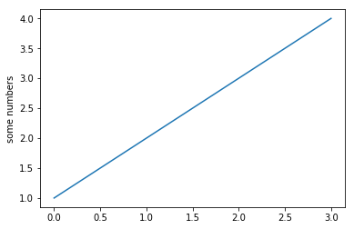

```python
%matplotlib inline

import matplotlib.pyplot as plt
plt.plot([1,2,3,4])
plt.ylabel('some numbers')
plt.show()
```

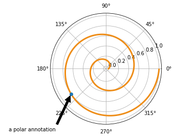

```python
fig = plt.figure()
ax = fig.add_subplot(111, polar=True)
r = np.arange(0,1,0.001)
theta = 2 * 2*np.pi * r
line, = ax.plot(theta, r, color='#ee8d18', lw=3)

ind = 800
thisr, thistheta = r[ind], theta[ind]
ax.plot([thistheta], [thisr], 'o')
ax.annotate('a polar annotation',
            xy=(thistheta, thisr),  # theta, radius
            xytext=(0.05, 0.05),    # fraction, fraction
            textcoords='figure fraction',
            arrowprops=dict(facecolor='black', shrink=0.05),
            horizontalalignment='left',
            verticalalignment='bottom',
            )
plt.show()
```

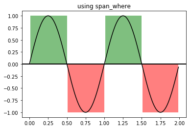

```python
import matplotlib.collections as collections


t = np.arange(0.0, 2, 0.01)
s1 = np.sin(2*np.pi*t)
s2 = 1.2*np.sin(4*np.pi*t)


fig, ax = plt.subplots()
ax.set_title('using span_where')
ax.plot(t, s1, color='black')
ax.axhline(0, color='black', lw=2)

collection = collections.BrokenBarHCollection.span_where(
    t, ymin=0, ymax=1, where=s1 > 0, facecolor='green', alpha=0.5)
ax.add_collection(collection)

collection = collections.BrokenBarHCollection.span_where(
    t, ymin=-1, ymax=0, where=s1 < 0, facecolor='red', alpha=0.5)
ax.add_collection(collection)


plt.show()
```

- References
  - [Official Gallery](https://matplotlib.org/gallery/index.html)
  - [Official Reference](https://matplotlib.org/contents.html)

## SciKit-learn

- Machine Learning for Python
- Implements most established ML algorithms and new ones are added regularly
- "Weka for Python"
- Highly tweakable
- Classification, Regression and Clustering
- Dimensionality Reduction, Model Selection and Preprocessing
- Includes the most common toy datasets for experimenting (Iris, Boston house prices, a reduced version of MNIST, etc.)

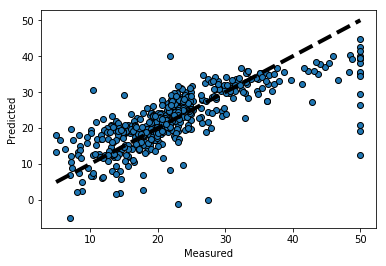

```python
from sklearn import datasets
from sklearn.model_selection import cross_val_predict
from sklearn import linear_model
import matplotlib.pyplot as plt

lr = linear_model.LinearRegression()
boston = datasets.load_boston()
y = boston.target

# cross_val_predict returns an array of the same size as `y` where each entry
# is a prediction obtained by cross validation:
predicted = cross_val_predict(lr, boston.data, y, cv=10)

fig, ax = plt.subplots()
ax.scatter(y, predicted, edgecolors=(0, 0, 0))
ax.plot([y.min(), y.max()], [y.min(), y.max()], 'k--', lw=4)
ax.set_xlabel('Measured')
ax.set_ylabel('Predicted')
plt.show()
```

- References
  - [Official Docs](http://scikit-learn.org/stable/documentation.html)
  - [Examples](http://scikit-learn.org/stable/auto_examples/index.html)

## Honorable mentions

### Keras

Neural networks API which can work on top of either **Theano** or **TensorFlow**. Very nice but can be a bit tricky to install, especially if you want to do computations on a GPU.

### NLTK

If you want to do Natural Language Processing in Python, NLTK is the traditionally safe choice. However, there seems to be quite a few NLP programmers who are discontent with developments regarding NLTK the last few years. This means that it is not improbable that there might be a fork in the near future with NLTK splitting and continuing along two different lines.

### Gensim

Library to work with vector space models, like distributional semantics (topic models, word embeddings, etc.) or recommender systems.

### Scrapy

Want to collect web data? Scrapy is a library to build spiders and web crawlers.

### Statsmodels

The Statsmodels library supplies a large chunk of the statisticians toolbox implementing traditional descriptive statistics and many standard tests and measures.

### SymPy

As there is a NumPy for numerical mathematics there is a SymPy for symbolic mathematics. Generally, computational science tends to be heavy on the numerical side but there are instances where symbolic math shines, especially where numerical equivalencies tend towards large precision errors.

### Bokeh

A package for making interactive vizualisations for the web. Similar to R's Shiny apps.

### Seaborn

Built on top of matplotlib and provides conveniency implementations for statistical vizualisations. "If matplotlib tries to make easy things easy and hard things possible, seaborn tries to make a well-defined set of hard things easy too." - *Michael Waskom*